# Risk Factor Analysis

## Outcome Variable

**Outcome Variable:** y_rate_wtkg

## Predictor Variables

**Intervention Variable:** cleanck

**Adjustment Set:**

- arm
- sex
- W_mage
- meducyrs
- feducyrs
- hhwealth_quart
- W_nrooms
- W_nhh
- W_nchldlt5
- trth2o
- impfloor
- delta_meducyrs
- delta_feducyrs
- delta_hhwealth_quart
- delta_W_nrooms
- delta_W_nhh
- delta_W_nchldlt5
- delta_trth2o
- delta_impfloor

## Stratifying Variables

The analysis was stratified on these variable(s):

- agecat
- studyid
- country

## Data Summary

| agecat | studyid | country | cleanck | n_cell | n |
| --- | --- | --- | --- | --- | --- |
| 0-3 months | CMC-V-BCS-2002 | INDIA | 1 | 147 | 331 |
| 0-3 months | CMC-V-BCS-2002 | INDIA | 0 | 184 | 331 |
| 0-3 months | GMS-Nepal | NEPAL | 1 | 7 | 460 |
| 0-3 months | GMS-Nepal | NEPAL | 0 | 453 | 460 |
| 0-3 months | IRC | INDIA | 1 | 223 | 386 |
| 0-3 months | IRC | INDIA | 0 | 163 | 386 |
| 0-3 months | MAL-ED | PERU | 1 | 1 | 1 |
| 0-3 months | MAL-ED | PERU | 0 | 0 | 1 |
| 0-3 months | MAL-ED | SOUTH AFRICA | 1 | 2 | 3 |
| 0-3 months | MAL-ED | SOUTH AFRICA | 0 | 1 | 3 |
| 0-3 months | NIH-Crypto | BANGLADESH | 1 | 337 | 550 |
| 0-3 months | NIH-Crypto | BANGLADESH | 0 | 213 | 550 |
| 0-3 months | PROVIDE | BANGLADESH | 1 | 529 | 640 |
| 0-3 months | PROVIDE | BANGLADESH | 0 | 111 | 640 |
| 3-6 months | CMC-V-BCS-2002 | INDIA | 1 | 138 | 322 |
| 3-6 months | CMC-V-BCS-2002 | INDIA | 0 | 184 | 322 |
| 3-6 months | GMS-Nepal | NEPAL | 1 | 6 | 424 |
| 3-6 months | GMS-Nepal | NEPAL | 0 | 418 | 424 |
| 3-6 months | IRC | INDIA | 1 | 225 | 391 |
| 3-6 months | IRC | INDIA | 0 | 166 | 391 |
| 3-6 months | MAL-ED | SOUTH AFRICA | 1 | 1 | 1 |
| 3-6 months | MAL-ED | SOUTH AFRICA | 0 | 0 | 1 |
| 3-6 months | NIH-Crypto | BANGLADESH | 1 | 320 | 532 |
| 3-6 months | NIH-Crypto | BANGLADESH | 0 | 212 | 532 |
| 3-6 months | PROVIDE | BANGLADESH | 1 | 494 | 601 |
| 3-6 months | PROVIDE | BANGLADESH | 0 | 107 | 601 |
| 6-9 months | CMC-V-BCS-2002 | INDIA | 1 | 141 | 325 |
| 6-9 months | CMC-V-BCS-2002 | INDIA | 0 | 184 | 325 |
| 6-9 months | GMS-Nepal | NEPAL | 1 | 8 | 429 |
| 6-9 months | GMS-Nepal | NEPAL | 0 | 421 | 429 |

[output cut: 68 more lines]

The following strata were considered:

- agecat: 0-3 months, studyid: CMC-V-BCS-2002, country: INDIA
- agecat: 0-3 months, studyid: GMS-Nepal, country: NEPAL
- agecat: 0-3 months, studyid: IRC, country: INDIA
- agecat: 0-3 months, studyid: MAL-ED, country: PERU
- agecat: 0-3 months, studyid: MAL-ED, country: SOUTH AFRICA
- agecat: 0-3 months, studyid: NIH-Crypto, country: BANGLADESH
- agecat: 0-3 months, studyid: PROVIDE, country: BANGLADESH
- agecat: 12-15 months, studyid: CMC-V-BCS-2002, country: INDIA
- agecat: 12-15 months, studyid: GMS-Nepal, country: NEPAL
- agecat: 12-15 months, studyid: IRC, country: INDIA
- agecat: 12-15 months, studyid: MAL-ED, country: SOUTH AFRICA
- agecat: 12-15 months, studyid: NIH-Crypto, country: BANGLADESH
- agecat: 12-15 months, studyid: PROVIDE, country: BANGLADESH
- agecat: 15-18 months, studyid: CMC-V-BCS-2002, country: INDIA
- agecat: 15-18 months, studyid: GMS-Nepal, country: NEPAL
- agecat: 15-18 months, studyid: IRC, country: INDIA
- agecat: 15-18 months, studyid: MAL-ED, country: SOUTH AFRICA
- agecat: 15-18 months, studyid: NIH-Crypto, country: BANGLADESH
- agecat: 15-18 months, studyid: PROVIDE, country: BANGLADESH
- agecat: 18-21 months, studyid: CMC-V-BCS-2002, country: INDIA
- agecat: 18-21 months, studyid: GMS-Nepal, country: NEPAL
- agecat: 18-21 months, studyid: IRC, country: INDIA
- agecat: 18-21 months, studyid: MAL-ED, country: SOUTH AFRICA
- agecat: 18-21 months, studyid: NIH-Crypto, country: BANGLADESH
- agecat: 18-21 months, studyid: PROVIDE, country: BANGLADESH
- agecat: 21-24 months, studyid: CMC-V-BCS-2002, country: INDIA
- agecat: 21-24 months, studyid: GMS-Nepal, country: NEPAL
- agecat: 21-24 months, studyid: IRC, country: INDIA
- agecat: 21-24 months, studyid: MAL-ED, country: SOUTH AFRICA
- agecat: 21-24 months, studyid: NIH-Crypto, country: BANGLADESH
- agecat: 21-24 months, studyid: PROVIDE, country: BANGLADESH
- agecat: 3-6 months, studyid: CMC-V-BCS-2002, country: INDIA
- agecat: 3-6 months, studyid: GMS-Nepal, country: NEPAL
- agecat: 3-6 months, studyid: IRC, country: INDIA
- agecat: 3-6 months, studyid: MAL-ED, country: SOUTH AFRICA
- agecat: 3-6 months, studyid: NIH-Crypto, country: BANGLADESH
- agecat: 3-6 months, studyid: PROVIDE, country: BANGLADESH
- agecat: 6-9 months, studyid: CMC-V-BCS-2002, country: INDIA
- agecat: 6-9 months, studyid: GMS-Nepal, country: NEPAL
- agecat: 6-9 months, studyid: IRC, country: INDIA
- agecat: 6-9 months, studyid: MAL-ED, country: SOUTH AFRICA
- agecat: 6-9 months, studyid: NIH-Crypto, country: BANGLADESH
- agecat: 6-9 months, studyid: PROVIDE, country: BANGLADESH
- agecat: 9-12 months, studyid: CMC-V-BCS-2002, country: INDIA
- agecat: 9-12 months, studyid: GMS-Nepal, country: NEPAL
- agecat: 9-12 months, studyid: IRC, country: INDIA
- agecat: 9-12 months, studyid: MAL-ED, country: SOUTH AFRICA
- agecat: 9-12 months, studyid: NIH-Crypto, country: BANGLADESH
- agecat: 9-12 months, studyid: PROVIDE, country: BANGLADESH

### Dropped Strata

Some strata were dropped due to rare outcomes:

- agecat: 0-3 months, studyid: MAL-ED, country: PERU
- agecat: 0-3 months, studyid: MAL-ED, country: SOUTH AFRICA
- agecat: 3-6 months, studyid: MAL-ED, country: SOUTH AFRICA
- agecat: 6-9 months, studyid: MAL-ED, country: SOUTH AFRICA
- agecat: 9-12 months, studyid: MAL-ED, country: SOUTH AFRICA
- agecat: 12-15 months, studyid: MAL-ED, country: SOUTH AFRICA
- agecat: 15-18 months, studyid: MAL-ED, country: SOUTH AFRICA
- agecat: 18-21 months, studyid: MAL-ED, country: SOUTH AFRICA
- agecat: 21-24 months, studyid: GMS-Nepal, country: NEPAL
- agecat: 21-24 months, studyid: MAL-ED, country: SOUTH AFRICA

## Methods Detail

We’re interested in the causal parameters $E[Y_a]$ for all values of $a \in \mathcal{A}$. These parameters represent the mean outcome if, possibly contrary to fact, we intervened to set all units to have $A=a$. Under the randomization and positivity assumptions, these are identified by the statistical parameters $\psi_a=E_W[E_{Y|A,W}(Y|A=a,W)]$. In addition, we’re interested in the mean of $Y$, $E[Y]$ under no intervention (the observed mean). We will estimate these parameters by using SuperLearner to fit the relevant likelihood factors – $E_{Y|A,W}(Y|A=a,W)$ and $p(A=a|W)$, and then updating our likelihood fit using a joint TMLE.

For unadjusted analyses ($W=\{\}$), initial likelihoods were estimated using Lrnr_glm to estimate the simple $E(Y|A)$ and Lrnr_mean to estimate $p(A)$. For adjusted analyses, a small library containing Lrnr_glmnet, Lrnr_xgboost, and Lrnr_mean was used.

Having estimated these parameters, we will then use the delta method to estimate relative risks and attributable risks relative to a prespecified baseline level of $A$.

# Results Detail

## Results Plots

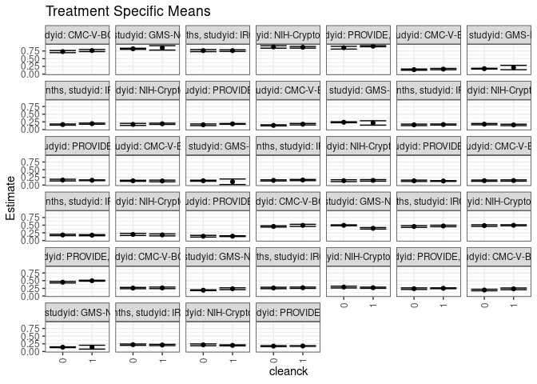

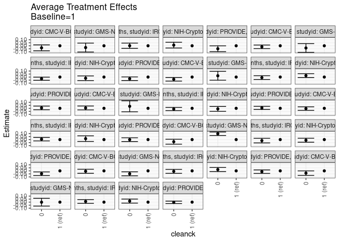

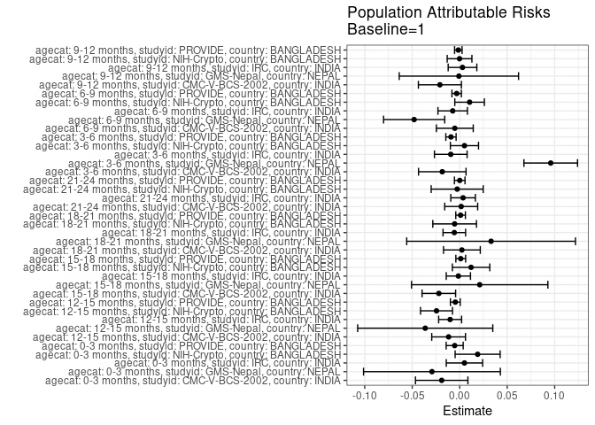

## Results Table

### Parameter: TSM

| agecat | studyid | country | intervention_level | baseline_level | estimate | ci_lower | ci_upper |
| --- | --- | --- | --- | --- | --- | --- | --- |
| 0-3 months | CMC-V-BCS-2002 | INDIA | 1 | NA | 0.7657185 | 0.7313513 | 0.8000857 |
| 0-3 months | CMC-V-BCS-2002 | INDIA | 0 | NA | 0.7313179 | 0.6965001 | 0.7661357 |
| 0-3 months | GMS-Nepal | NEPAL | 1 | NA | 0.8517935 | 0.7801961 | 0.9233909 |
| 0-3 months | GMS-Nepal | NEPAL | 0 | NA | 0.8221249 | 0.8038873 | 0.8403626 |
| 0-3 months | IRC | INDIA | 1 | NA | 0.7619392 | 0.7336599 | 0.7902186 |
| 0-3 months | IRC | INDIA | 0 | NA | 0.7628757 | 0.7299955 | 0.7957560 |
| 0-3 months | NIH-Crypto | BANGLADESH | 1 | NA | 0.8712119 | 0.8434394 | 0.8989844 |
| 0-3 months | NIH-Crypto | BANGLADESH | 0 | NA | 0.8820579 | 0.8428692 | 0.9212465 |
| 0-3 months | PROVIDE | BANGLADESH | 1 | NA | 0.9069416 | 0.8892030 | 0.9246801 |
| 0-3 months | PROVIDE | BANGLADESH | 0 | NA | 0.8576045 | 0.8126504 | 0.9025585 |
| 3-6 months | CMC-V-BCS-2002 | INDIA | 1 | NA | 0.4935068 | 0.4588051 | 0.5282085 |
| 3-6 months | CMC-V-BCS-2002 | INDIA | 0 | NA | 0.4583396 | 0.4364833 | 0.4801960 |
| 3-6 months | GMS-Nepal | NEPAL | 1 | NA | 0.3977899 | 0.3730672 | 0.4225126 |
| 3-6 months | GMS-Nepal | NEPAL | 0 | NA | 0.4950234 | 0.4799980 | 0.5100489 |
| 3-6 months | IRC | INDIA | 1 | NA | 0.4734196 | 0.4478309 | 0.4990083 |
| 3-6 months | IRC | INDIA | 0 | NA | 0.4565019 | 0.4278266 | 0.4851772 |
| 3-6 months | NIH-Crypto | BANGLADESH | 1 | NA | 0.4961744 | 0.4774617 | 0.5148871 |
| 3-6 months | NIH-Crypto | BANGLADESH | 0 | NA | 0.4857422 | 0.4586658 | 0.5128186 |
| 3-6 months | PROVIDE | BANGLADESH | 1 | NA | 0.4982575 | 0.4830776 | 0.5134373 |
| 3-6 months | PROVIDE | BANGLADESH | 0 | NA | 0.4502241 | 0.4245349 | 0.4759133 |
| 6-9 months | CMC-V-BCS-2002 | INDIA | 1 | NA | 0.2647471 | 0.2387924 | 0.2907018 |
| 6-9 months | CMC-V-BCS-2002 | INDIA | 0 | NA | 0.2583733 | 0.2370911 | 0.2796556 |
| 6-9 months | GMS-Nepal | NEPAL | 1 | NA | 0.2373516 | 0.2071781 | 0.2675251 |
| 6-9 months | GMS-Nepal | NEPAL | 0 | NA | 0.1884564 | 0.1750948 | 0.2018179 |
| 6-9 months | IRC | INDIA | 1 | NA | 0.2699683 | 0.2485210 | 0.2914155 |
| 6-9 months | IRC | INDIA | 0 | NA | 0.2619893 | 0.2385483 | 0.2854303 |
| 6-9 months | NIH-Crypto | BANGLADESH | 1 | NA | 0.2695116 | 0.2505253 | 0.2884979 |
| 6-9 months | NIH-Crypto | BANGLADESH | 0 | NA | 0.2913870 | 0.2626839 | 0.3200902 |
| 6-9 months | PROVIDE | BANGLADESH | 1 | NA | 0.2523501 | 0.2383903 | 0.2663099 |
| 6-9 months | PROVIDE | BANGLADESH | 0 | NA | 0.2388174 | 0.2135015 | 0.2641333 |
| 9-12 months | CMC-V-BCS-2002 | INDIA | 1 | NA | 0.2331709 | 0.2056182 | 0.2607235 |
| 9-12 months | CMC-V-BCS-2002 | INDIA | 0 | NA | 0.1954120 | 0.1705725 | 0.2202515 |
| 9-12 months | GMS-Nepal | NEPAL | 1 | NA | 0.1404390 | 0.0774489 | 0.2034290 |
| 9-12 months | GMS-Nepal | NEPAL | 0 | NA | 0.1395699 | 0.1259592 | 0.1531806 |
| 9-12 months | IRC | INDIA | 1 | NA | 0.2119333 | 0.1908324 | 0.2330342 |
| 9-12 months | IRC | INDIA | 0 | NA | 0.2226698 | 0.1999876 | 0.2453520 |
| 9-12 months | NIH-Crypto | BANGLADESH | 1 | NA | 0.1999515 | 0.1833648 | 0.2165381 |
| 9-12 months | NIH-Crypto | BANGLADESH | 0 | NA | 0.2175367 | 0.1882024 | 0.2468710 |
| 9-12 months | PROVIDE | BANGLADESH | 1 | NA | 0.1789699 | 0.1682466 | 0.1896933 |
| 9-12 months | PROVIDE | BANGLADESH | 0 | NA | 0.1758459 | 0.1586217 | 0.1930701 |
| 12-15 months | CMC-V-BCS-2002 | INDIA | 1 | NA | 0.1621418 | 0.1400812 | 0.1842024 |
| 12-15 months | CMC-V-BCS-2002 | INDIA | 0 | NA | 0.1445437 | 0.1245795 | 0.1645079 |
| 12-15 months | GMS-Nepal | NEPAL | 1 | NA | 0.2124379 | 0.1407820 | 0.2840939 |
| 12-15 months | GMS-Nepal | NEPAL | 0 | NA | 0.1754264 | 0.1615923 | 0.1892604 |
| 12-15 months | IRC | INDIA | 1 | NA | 0.1907755 | 0.1728192 | 0.2087319 |
| 12-15 months | IRC | INDIA | 0 | NA | 0.1630554 | 0.1440460 | 0.1820649 |
| 12-15 months | NIH-Crypto | BANGLADESH | 1 | NA | 0.1878480 | 0.1682934 | 0.2074027 |
| 12-15 months | NIH-Crypto | BANGLADESH | 0 | NA | 0.1678755 | 0.1348133 | 0.2009376 |
| 12-15 months | PROVIDE | BANGLADESH | 1 | NA | 0.1846459 | 0.1715142 | 0.1977776 |
| 12-15 months | PROVIDE | BANGLADESH | 0 | NA | 0.1567395 | 0.1298137 | 0.1836654 |
| 15-18 months | CMC-V-BCS-2002 | INDIA | 1 | NA | 0.1741424 | 0.1502150 | 0.1980698 |
| 15-18 months | CMC-V-BCS-2002 | INDIA | 0 | NA | 0.1370356 | 0.1191434 | 0.1549277 |
| 15-18 months | GMS-Nepal | NEPAL | 1 | NA | 0.2159802 | 0.1441626 | 0.2877979 |
| 15-18 months | GMS-Nepal | NEPAL | 0 | NA | 0.2374486 | 0.2212279 | 0.2536693 |
| 15-18 months | IRC | INDIA | 1 | NA | 0.1635598 | 0.1450202 | 0.1820995 |
| 15-18 months | IRC | INDIA | 0 | NA | 0.1540708 | 0.1294123 | 0.1787293 |
| 15-18 months | NIH-Crypto | BANGLADESH | 1 | NA | 0.1517259 | 0.1282772 | 0.1751746 |
| 15-18 months | NIH-Crypto | BANGLADESH | 0 | NA | 0.1754266 | 0.1546026 | 0.1962505 |
| 15-18 months | PROVIDE | BANGLADESH | 1 | NA | 0.1552575 | 0.1421574 | 0.1683575 |
| 15-18 months | PROVIDE | BANGLADESH | 0 | NA | 0.1618561 | 0.1348219 | 0.1888904 |
| 18-21 months | CMC-V-BCS-2002 | INDIA | 1 | NA | 0.1329157 | 0.1062273 | 0.1596041 |
| 18-21 months | CMC-V-BCS-2002 | INDIA | 0 | NA | 0.1387787 | 0.1214203 | 0.1561371 |
| 18-21 months | GMS-Nepal | NEPAL | 1 | NA | 0.1069112 | 0.0173514 | 0.1964710 |
| 18-21 months | GMS-Nepal | NEPAL | 0 | NA | 0.1405466 | 0.1237035 | 0.1573898 |
| 18-21 months | IRC | INDIA | 1 | NA | 0.1633328 | 0.1445910 | 0.1820746 |
| 18-21 months | IRC | INDIA | 0 | NA | 0.1516385 | 0.1327087 | 0.1705683 |
| 18-21 months | NIH-Crypto | BANGLADESH | 1 | NA | 0.1513483 | 0.1261235 | 0.1765731 |
| 18-21 months | NIH-Crypto | BANGLADESH | 0 | NA | 0.1420808 | 0.1115668 | 0.1725948 |
| 18-21 months | PROVIDE | BANGLADESH | 1 | NA | 0.1315527 | 0.1184839 | 0.1446215 |
| 18-21 months | PROVIDE | BANGLADESH | 0 | NA | 0.1384906 | 0.1158742 | 0.1611070 |
| 21-24 months | CMC-V-BCS-2002 | INDIA | 1 | NA | 0.1468782 | 0.1259760 | 0.1677803 |
| 21-24 months | CMC-V-BCS-2002 | INDIA | 0 | NA | 0.1426226 | 0.1227402 | 0.1625049 |
| 21-24 months | IRC | INDIA | 1 | NA | 0.1739708 | 0.1548685 | 0.1930731 |
| 21-24 months | IRC | INDIA | 0 | NA | 0.1811158 | 0.1594933 | 0.2027383 |
| 21-24 months | NIH-Crypto | BANGLADESH | 1 | NA | 0.1834944 | 0.1519602 | 0.2150286 |
| 21-24 months | NIH-Crypto | BANGLADESH | 0 | NA | 0.1990229 | 0.1647424 | 0.2333033 |
| 21-24 months | PROVIDE | BANGLADESH | 1 | NA | 0.1419412 | 0.1293227 | 0.1545598 |
| 21-24 months | PROVIDE | BANGLADESH | 0 | NA | 0.1403961 | 0.1124434 | 0.1683487 |

### Parameter: E(Y)

| agecat | studyid | country | intervention_level | baseline_level | estimate | ci_lower | ci_upper |
| --- | --- | --- | --- | --- | --- | --- | --- |
| 0-3 months | CMC-V-BCS-2002 | INDIA | NA | NA | 0.7467559 | 0.7230662 | 0.7704455 |
| 0-3 months | GMS-Nepal | NEPAL | NA | NA | 0.8225764 | 0.8047018 | 0.8404511 |
| 0-3 months | IRC | INDIA | NA | NA | 0.7669350 | 0.7473009 | 0.7865692 |
| 0-3 months | NIH-Crypto | BANGLADESH | NA | NA | 0.8901037 | 0.8738687 | 0.9063387 |
| 0-3 months | PROVIDE | BANGLADESH | NA | NA | 0.9016472 | 0.8868914 | 0.9164029 |
| 3-6 months | CMC-V-BCS-2002 | INDIA | NA | NA | 0.4751567 | 0.4562440 | 0.4940693 |
| 3-6 months | GMS-Nepal | NEPAL | NA | NA | 0.4936475 | 0.4789438 | 0.5083512 |
| 3-6 months | IRC | INDIA | NA | NA | 0.4640137 | 0.4462252 | 0.4818022 |
| 3-6 months | NIH-Crypto | BANGLADESH | NA | NA | 0.5011716 | 0.4886950 | 0.5136482 |
| 3-6 months | PROVIDE | BANGLADESH | NA | NA | 0.4890611 | 0.4760060 | 0.5021163 |
| 6-9 months | CMC-V-BCS-2002 | INDIA | NA | NA | 0.2595889 | 0.2435057 | 0.2756721 |
| 6-9 months | GMS-Nepal | NEPAL | NA | NA | 0.1893682 | 0.1763037 | 0.2024326 |
| 6-9 months | IRC | INDIA | NA | NA | 0.2625992 | 0.2484830 | 0.2767153 |
| 6-9 months | NIH-Crypto | BANGLADESH | NA | NA | 0.2799276 | 0.2681500 | 0.2917053 |
| 6-9 months | PROVIDE | BANGLADESH | NA | NA | 0.2491653 | 0.2371134 | 0.2612172 |
| 9-12 months | CMC-V-BCS-2002 | INDIA | NA | NA | 0.2123308 | 0.1948351 | 0.2298265 |
| 9-12 months | GMS-Nepal | NEPAL | NA | NA | 0.1395867 | 0.1262232 | 0.1529503 |
| 9-12 months | IRC | INDIA | NA | NA | 0.2148825 | 0.2005353 | 0.2292297 |
| 9-12 months | NIH-Crypto | BANGLADESH | NA | NA | 0.1997882 | 0.1879938 | 0.2115826 |
| 9-12 months | PROVIDE | BANGLADESH | NA | NA | 0.1775316 | 0.1681968 | 0.1868664 |
| 12-15 months | CMC-V-BCS-2002 | INDIA | NA | NA | 0.1504668 | 0.1366572 | 0.1642764 |
| 12-15 months | GMS-Nepal | NEPAL | NA | NA | 0.1761486 | 0.1625329 | 0.1897642 |
| 12-15 months | IRC | INDIA | NA | NA | 0.1807123 | 0.1677267 | 0.1936978 |
| 12-15 months | NIH-Crypto | BANGLADESH | NA | NA | 0.1634289 | 0.1511149 | 0.1757429 |
| 12-15 months | PROVIDE | BANGLADESH | NA | NA | 0.1800324 | 0.1683272 | 0.1917375 |
| 15-18 months | CMC-V-BCS-2002 | INDIA | NA | NA | 0.1521835 | 0.1380291 | 0.1663379 |
| 15-18 months | GMS-Nepal | NEPAL | NA | NA | 0.2370510 | 0.2211319 | 0.2529701 |
| 15-18 months | IRC | INDIA | NA | NA | 0.1621526 | 0.1485252 | 0.1757800 |
| 15-18 months | NIH-Crypto | BANGLADESH | NA | NA | 0.1636945 | 0.1517037 | 0.1756852 |
| 15-18 months | PROVIDE | BANGLADESH | NA | NA | 0.1563514 | 0.1445823 | 0.1681205 |
| 18-21 months | CMC-V-BCS-2002 | INDIA | NA | NA | 0.1352327 | 0.1200477 | 0.1504178 |
| 18-21 months | GMS-Nepal | NEPAL | NA | NA | 0.1399681 | 0.1233886 | 0.1565477 |
| 18-21 months | IRC | INDIA | NA | NA | 0.1576598 | 0.1441337 | 0.1711860 |
| 18-21 months | NIH-Crypto | BANGLADESH | NA | NA | 0.1460095 | 0.1336664 | 0.1583525 |
| 18-21 months | PROVIDE | BANGLADESH | NA | NA | 0.1324882 | 0.1210438 | 0.1439326 |
| 21-24 months | CMC-V-BCS-2002 | INDIA | NA | NA | 0.1484491 | 0.1344875 | 0.1624106 |
| 21-24 months | IRC | INDIA | NA | NA | 0.1775274 | 0.1635028 | 0.1915520 |
| 21-24 months | NIH-Crypto | BANGLADESH | NA | NA | 0.1808389 | 0.1670473 | 0.1946304 |
| 21-24 months | PROVIDE | BANGLADESH | NA | NA | 0.1419705 | 0.1305335 | 0.1534075 |

### Parameter: ATE

| agecat | studyid | country | intervention_level | baseline_level | estimate | ci_lower | ci_upper |
| --- | --- | --- | --- | --- | --- | --- | --- |
| 0-3 months | CMC-V-BCS-2002 | INDIA | 1 | 1 | 0.0000000 | 0.0000000 | 0.0000000 |
| 0-3 months | CMC-V-BCS-2002 | INDIA | 0 | 1 | -0.0344006 | -0.0831797 | 0.0143785 |
| 0-3 months | GMS-Nepal | NEPAL | 1 | 1 | 0.0000000 | 0.0000000 | 0.0000000 |
| 0-3 months | GMS-Nepal | NEPAL | 0 | 1 | -0.0296686 | -0.1035523 | 0.0442151 |
| 0-3 months | IRC | INDIA | 1 | 1 | 0.0000000 | 0.0000000 | 0.0000000 |
| 0-3 months | IRC | INDIA | 0 | 1 | 0.0009365 | -0.0424327 | 0.0443057 |
| 0-3 months | NIH-Crypto | BANGLADESH | 1 | 1 | 0.0000000 | 0.0000000 | 0.0000000 |
| 0-3 months | NIH-Crypto | BANGLADESH | 0 | 1 | 0.0108460 | -0.0371989 | 0.0588909 |
| 0-3 months | PROVIDE | BANGLADESH | 1 | 1 | 0.0000000 | 0.0000000 | 0.0000000 |
| 0-3 months | PROVIDE | BANGLADESH | 0 | 1 | -0.0493371 | -0.0977200 | -0.0009542 |
| 3-6 months | CMC-V-BCS-2002 | INDIA | 1 | 1 | 0.0000000 | 0.0000000 | 0.0000000 |
| 3-6 months | CMC-V-BCS-2002 | INDIA | 0 | 1 | -0.0351671 | -0.0761064 | 0.0057721 |
| 3-6 months | GMS-Nepal | NEPAL | 1 | 1 | 0.0000000 | 0.0000000 | 0.0000000 |
| 3-6 months | GMS-Nepal | NEPAL | 0 | 1 | 0.0972335 | 0.0683030 | 0.1261641 |
| 3-6 months | IRC | INDIA | 1 | 1 | 0.0000000 | 0.0000000 | 0.0000000 |
| 3-6 months | IRC | INDIA | 0 | 1 | -0.0169177 | -0.0551923 | 0.0213569 |
| 3-6 months | NIH-Crypto | BANGLADESH | 1 | 1 | 0.0000000 | 0.0000000 | 0.0000000 |
| 3-6 months | NIH-Crypto | BANGLADESH | 0 | 1 | -0.0104322 | -0.0434970 | 0.0226326 |
| 3-6 months | PROVIDE | BANGLADESH | 1 | 1 | 0.0000000 | 0.0000000 | 0.0000000 |
| 3-6 months | PROVIDE | BANGLADESH | 0 | 1 | -0.0480333 | -0.0780510 | -0.0180157 |
| 6-9 months | CMC-V-BCS-2002 | INDIA | 1 | 1 | 0.0000000 | 0.0000000 | 0.0000000 |
| 6-9 months | CMC-V-BCS-2002 | INDIA | 0 | 1 | -0.0063738 | -0.0399619 | 0.0272143 |
| 6-9 months | GMS-Nepal | NEPAL | 1 | 1 | 0.0000000 | 0.0000000 | 0.0000000 |
| 6-9 months | GMS-Nepal | NEPAL | 0 | 1 | -0.0488953 | -0.0818949 | -0.0158957 |
| 6-9 months | IRC | INDIA | 1 | 1 | 0.0000000 | 0.0000000 | 0.0000000 |
| 6-9 months | IRC | INDIA | 0 | 1 | -0.0079790 | -0.0403219 | 0.0243640 |
| 6-9 months | NIH-Crypto | BANGLADESH | 1 | 1 | 0.0000000 | 0.0000000 | 0.0000000 |
| 6-9 months | NIH-Crypto | BANGLADESH | 0 | 1 | 0.0218755 | -0.0125637 | 0.0563146 |
| 6-9 months | PROVIDE | BANGLADESH | 1 | 1 | 0.0000000 | 0.0000000 | 0.0000000 |
| 6-9 months | PROVIDE | BANGLADESH | 0 | 1 | -0.0135327 | -0.0423782 | 0.0153129 |
| 9-12 months | CMC-V-BCS-2002 | INDIA | 1 | 1 | 0.0000000 | 0.0000000 | 0.0000000 |
| 9-12 months | CMC-V-BCS-2002 | INDIA | 0 | 1 | -0.0377589 | -0.0749673 | -0.0005505 |
| 9-12 months | GMS-Nepal | NEPAL | 1 | 1 | 0.0000000 | 0.0000000 | 0.0000000 |
| 9-12 months | GMS-Nepal | NEPAL | 0 | 1 | -0.0008691 | -0.0653129 | 0.0635747 |
| 9-12 months | IRC | INDIA | 1 | 1 | 0.0000000 | 0.0000000 | 0.0000000 |
| 9-12 months | IRC | INDIA | 0 | 1 | 0.0107364 | -0.0203684 | 0.0418413 |
| 9-12 months | NIH-Crypto | BANGLADESH | 1 | 1 | 0.0000000 | 0.0000000 | 0.0000000 |
| 9-12 months | NIH-Crypto | BANGLADESH | 0 | 1 | 0.0175852 | -0.0159628 | 0.0511332 |
| 9-12 months | PROVIDE | BANGLADESH | 1 | 1 | 0.0000000 | 0.0000000 | 0.0000000 |
| 9-12 months | PROVIDE | BANGLADESH | 0 | 1 | -0.0031240 | -0.0234144 | 0.0171663 |
| 12-15 months | CMC-V-BCS-2002 | INDIA | 1 | 1 | 0.0000000 | 0.0000000 | 0.0000000 |
| 12-15 months | CMC-V-BCS-2002 | INDIA | 0 | 1 | -0.0175981 | -0.0472713 | 0.0120750 |
| 12-15 months | GMS-Nepal | NEPAL | 1 | 1 | 0.0000000 | 0.0000000 | 0.0000000 |
| 12-15 months | GMS-Nepal | NEPAL | 0 | 1 | -0.0370116 | -0.1099908 | 0.0359676 |
| 12-15 months | IRC | INDIA | 1 | 1 | 0.0000000 | 0.0000000 | 0.0000000 |
| 12-15 months | IRC | INDIA | 0 | 1 | -0.0277201 | -0.0539248 | -0.0015154 |
| 12-15 months | NIH-Crypto | BANGLADESH | 1 | 1 | 0.0000000 | 0.0000000 | 0.0000000 |
| 12-15 months | NIH-Crypto | BANGLADESH | 0 | 1 | -0.0199726 | -0.0585952 | 0.0186501 |
| 12-15 months | PROVIDE | BANGLADESH | 1 | 1 | 0.0000000 | 0.0000000 | 0.0000000 |
| 12-15 months | PROVIDE | BANGLADESH | 0 | 1 | -0.0279064 | -0.0579277 | 0.0021149 |
| 15-18 months | CMC-V-BCS-2002 | INDIA | 1 | 1 | 0.0000000 | 0.0000000 | 0.0000000 |
| 15-18 months | CMC-V-BCS-2002 | INDIA | 0 | 1 | -0.0371069 | -0.0670249 | -0.0071888 |
| 15-18 months | GMS-Nepal | NEPAL | 1 | 1 | 0.0000000 | 0.0000000 | 0.0000000 |
| 15-18 months | GMS-Nepal | NEPAL | 0 | 1 | 0.0214684 | -0.0521583 | 0.0950951 |
| 15-18 months | IRC | INDIA | 1 | 1 | 0.0000000 | 0.0000000 | 0.0000000 |
| 15-18 months | IRC | INDIA | 0 | 1 | -0.0094890 | -0.0404769 | 0.0214989 |
| 15-18 months | NIH-Crypto | BANGLADESH | 1 | 1 | 0.0000000 | 0.0000000 | 0.0000000 |
| 15-18 months | NIH-Crypto | BANGLADESH | 0 | 1 | 0.0237007 | -0.0076816 | 0.0550830 |
| 15-18 months | PROVIDE | BANGLADESH | 1 | 1 | 0.0000000 | 0.0000000 | 0.0000000 |
| 15-18 months | PROVIDE | BANGLADESH | 0 | 1 | 0.0065986 | -0.0236703 | 0.0368676 |
| 18-21 months | CMC-V-BCS-2002 | INDIA | 1 | 1 | 0.0000000 | 0.0000000 | 0.0000000 |
| 18-21 months | CMC-V-BCS-2002 | INDIA | 0 | 1 | 0.0058630 | -0.0261789 | 0.0379049 |
| 18-21 months | GMS-Nepal | NEPAL | 1 | 1 | 0.0000000 | 0.0000000 | 0.0000000 |
| 18-21 months | GMS-Nepal | NEPAL | 0 | 1 | 0.0336355 | -0.0574944 | 0.1247653 |
| 18-21 months | IRC | INDIA | 1 | 1 | 0.0000000 | 0.0000000 | 0.0000000 |
| 18-21 months | IRC | INDIA | 0 | 1 | -0.0116943 | -0.0384112 | 0.0150227 |
| 18-21 months | NIH-Crypto | BANGLADESH | 1 | 1 | 0.0000000 | 0.0000000 | 0.0000000 |
| 18-21 months | NIH-Crypto | BANGLADESH | 0 | 1 | -0.0092675 | -0.0490160 | 0.0304811 |
| 18-21 months | PROVIDE | BANGLADESH | 1 | 1 | 0.0000000 | 0.0000000 | 0.0000000 |
| 18-21 months | PROVIDE | BANGLADESH | 0 | 1 | 0.0069379 | -0.0192293 | 0.0331051 |
| 21-24 months | CMC-V-BCS-2002 | INDIA | 1 | 1 | 0.0000000 | 0.0000000 | 0.0000000 |
| 21-24 months | CMC-V-BCS-2002 | INDIA | 0 | 1 | -0.0042556 | -0.0334138 | 0.0249026 |
| 21-24 months | IRC | INDIA | 1 | 1 | 0.0000000 | 0.0000000 | 0.0000000 |
| 21-24 months | IRC | INDIA | 0 | 1 | 0.0071450 | -0.0219079 | 0.0361978 |
| 21-24 months | NIH-Crypto | BANGLADESH | 1 | 1 | 0.0000000 | 0.0000000 | 0.0000000 |
| 21-24 months | NIH-Crypto | BANGLADESH | 0 | 1 | 0.0155285 | -0.0311558 | 0.0622128 |
| 21-24 months | PROVIDE | BANGLADESH | 1 | 1 | 0.0000000 | 0.0000000 | 0.0000000 |
| 21-24 months | PROVIDE | BANGLADESH | 0 | 1 | -0.0015452 | -0.0322968 | 0.0292065 |

### Parameter: PAR

| agecat | studyid | country | intervention_level | baseline_level | estimate | ci_lower | ci_upper |
| --- | --- | --- | --- | --- | --- | --- | --- |
| 0-3 months | CMC-V-BCS-2002 | INDIA | 1 | NA | -0.0189626 | -0.0465714 | 0.0086462 |
| 0-3 months | GMS-Nepal | NEPAL | 1 | NA | -0.0292171 | -0.1012545 | 0.0428203 |
| 0-3 months | IRC | INDIA | 1 | NA | 0.0049958 | -0.0141391 | 0.0241306 |
| 0-3 months | NIH-Crypto | BANGLADESH | 1 | NA | 0.0188918 | -0.0048208 | 0.0426044 |
| 0-3 months | PROVIDE | BANGLADESH | 1 | NA | -0.0052944 | -0.0142573 | 0.0036684 |
| 3-6 months | CMC-V-BCS-2002 | INDIA | 1 | NA | -0.0183501 | -0.0433590 | 0.0066588 |
| 3-6 months | GMS-Nepal | NEPAL | 1 | NA | 0.0958576 | 0.0676291 | 0.1240861 |
| 3-6 months | IRC | INDIA | 1 | NA | -0.0094059 | -0.0266100 | 0.0077983 |
| 3-6 months | NIH-Crypto | BANGLADESH | 1 | NA | 0.0049972 | -0.0098298 | 0.0198241 |
| 3-6 months | PROVIDE | BANGLADESH | 1 | NA | -0.0091963 | -0.0146077 | -0.0037849 |
| 6-9 months | CMC-V-BCS-2002 | INDIA | 1 | NA | -0.0051582 | -0.0245729 | 0.0142565 |
| 6-9 months | GMS-Nepal | NEPAL | 1 | NA | -0.0479835 | -0.0801642 | -0.0158028 |
| 6-9 months | IRC | INDIA | 1 | NA | -0.0073691 | -0.0228890 | 0.0081508 |
| 6-9 months | NIH-Crypto | BANGLADESH | 1 | NA | 0.0104161 | -0.0051591 | 0.0259912 |
| 6-9 months | PROVIDE | BANGLADESH | 1 | NA | -0.0031847 | -0.0081629 | 0.0017934 |
| 9-12 months | CMC-V-BCS-2002 | INDIA | 1 | NA | -0.0208401 | -0.0435035 | 0.0018234 |
| 9-12 months | GMS-Nepal | NEPAL | 1 | NA | -0.0008522 | -0.0636849 | 0.0619804 |
| 9-12 months | IRC | INDIA | 1 | NA | 0.0029492 | -0.0121425 | 0.0180409 |
| 9-12 months | NIH-Crypto | BANGLADESH | 1 | NA | -0.0001633 | -0.0131802 | 0.0128536 |
| 9-12 months | PROVIDE | BANGLADESH | 1 | NA | -0.0014383 | -0.0053843 | 0.0025076 |
| 12-15 months | CMC-V-BCS-2002 | INDIA | 1 | NA | -0.0116750 | -0.0294404 | 0.0060904 |
| 12-15 months | GMS-Nepal | NEPAL | 1 | NA | -0.0362894 | -0.1074458 | 0.0348670 |
| 12-15 months | IRC | INDIA | 1 | NA | -0.0100633 | -0.0221454 | 0.0020188 |
| 12-15 months | NIH-Crypto | BANGLADESH | 1 | NA | -0.0244191 | -0.0412585 | -0.0075797 |
| 12-15 months | PROVIDE | BANGLADESH | 1 | NA | -0.0046136 | -0.0097808 | 0.0005537 |
| 15-18 months | CMC-V-BCS-2002 | INDIA | 1 | NA | -0.0219589 | -0.0396303 | -0.0042875 |
| 15-18 months | GMS-Nepal | NEPAL | 1 | NA | 0.0210708 | -0.0507157 | 0.0928573 |
| 15-18 months | IRC | INDIA | 1 | NA | -0.0014072 | -0.0141742 | 0.0113597 |
| 15-18 months | NIH-Crypto | BANGLADESH | 1 | NA | 0.0119686 | -0.0077405 | 0.0316776 |
| 15-18 months | PROVIDE | BANGLADESH | 1 | NA | 0.0010940 | -0.0040566 | 0.0062445 |
| 18-21 months | CMC-V-BCS-2002 | INDIA | 1 | NA | 0.0023170 | -0.0170359 | 0.0216699 |
| 18-21 months | GMS-Nepal | NEPAL | 1 | NA | 0.0330570 | -0.0557956 | 0.1219096 |
| 18-21 months | IRC | INDIA | 1 | NA | -0.0056730 | -0.0175594 | 0.0062134 |
| 18-21 months | NIH-Crypto | BANGLADESH | 1 | NA | -0.0053388 | -0.0283212 | 0.0176436 |
| 18-21 months | PROVIDE | BANGLADESH | 1 | NA | 0.0009355 | -0.0041311 | 0.0060021 |
| 21-24 months | CMC-V-BCS-2002 | INDIA | 1 | NA | 0.0015709 | -0.0157790 | 0.0189208 |
| 21-24 months | IRC | INDIA | 1 | NA | 0.0035565 | -0.0093845 | 0.0164976 |
| 21-24 months | NIH-Crypto | BANGLADESH | 1 | NA | -0.0026555 | -0.0300472 | 0.0247362 |
| 21-24 months | PROVIDE | BANGLADESH | 1 | NA | 0.0000292 | -0.0055493 | 0.0056078 |